# Relatedness

In this exercise you will run a complete relatedness estimation pipeline on a real SNP dataset. By the end you should be able to:

[figure not shown]

```
#############################################################
# ALL PATHS ARE SET HERE
# If the data moves, this is the ONLY cell you need to change.
# No cell below this one uses a full path.
#############################################################

# where the shared data lives
DATA=/course/data/current_data/relatedness

# the shared R plotting helpers
SCRIPTS=/course/data/current_data/scripts

# where you will do the exercise
WORK=$HOME/relatedness_animal
mkdir -p $WORK
cd $WORK

# write the paths out so every later bash cell can source them back
cat > $WORK/env.sh <<EOF
export DATA=$DATA
export SCRIPTS=$SCRIPTS
export WORK=$WORK
export RELATEADMIX=$DATA/relateAdmix
cd $WORK
EOF

echo "working folder: $(pwd)"
echo
echo "data files available:"
ls $DATA
```

```
# R cannot source env.sh, so read the paths out of it rather than repeating them
env <- readLines(path.expand("~/relatedness_animal/env.sh"))
getvar <- function(k) sub(paste0('^export ', k, '='), '', grep(paste0('^export ', k, '='), env, value = TRUE)[1])
DATA    <- getvar("DATA")
SCRIPTS <- getvar("SCRIPTS")
WORK    <- getvar("WORK")
setwd(WORK)
getwd()
```

'/davidData/data/course/.nbrender_home/relatedness_animal'

We will be using the data set of called genotypes from different reindeer populations in Greenland (cold!!).

Here is a map from Greenland with the different reindeer populations:

[figure not shown]

## STEP 1 — Data Preparation

### 1a. Inspect the Reindeer dataset

```
source ~/relatedness_animal/env.sh

# How many individuals and SNPs?
wc -l $DATA/Reindeer.fam
wc -l $DATA/Reindeer.bim

# Population breakdown
cut -f2 $DATA/Reindeer.fam | sort | uniq -c
```

```
111 /course/data/current_data/relatedness/Reindeer.fam
2818432 /course/data/current_data/relatedness/Reindeer.bim
     15 Akia/Maniitsoq
      9 Ameralik
      6 Inglefield
      3 Ivittuut
     21 Kangerlussuaq-Sisimiut
     10 Naternaq
     13 Neria
      2 Nuussuaq
      3 Olrik_Fjord
     10 Qassit
      5 Qeqertarsuatsiaat
     14 South_Greenland
```

```
# run to start quiz
from jupyterquiz import display_quiz
display_quiz('https://raw.githubusercontent.com/popgenDK/courses/main/current_exercises/relatedness_diversity/quiz/dataset_summary.json')
```

The next command takes a while to run so go for a walk and run the next command in 5 minutes

```
source ~/relatedness_animal/env.sh

echo "This command was used to generate the precomputed files:"
echo "PCAone -b $DATA/Reindeer -k 6 --ld -o pcaone"

echo
echo "[20/08/2026-10:46:11] initialize window-based RSVD (winSVD) with in-core
[20/08/2026-10:46:11] permuting data matrix by columns in place
[20/08/2026-10:46:23] running of epoch =  1, diff = 0.026404
[20/08/2026-10:46:28] running of epoch =  2, diff = 0.000399
[20/08/2026-10:46:32] running of epoch =  3, diff = 0.000230
[20/08/2026-10:46:37] running of epoch =  4, diff = 0.000031
PCAone winSVD converged but continues running to get S and V.
[20/08/2026-10:46:42] running of epoch =  5, diff = 0.000083
PCAone winSVD converged but continues running to get S and V.
[20/08/2026-10:46:46] running of epoch =  6, diff = 0.000084
[20/08/2026-10:46:46] stops at epoch =  7
[20/08/2026-10:46:46] ld-stats=0: calculate the ancestry adjusted LD matrix!
[20/08/2026-10:46:50] save matched sites in .mbim file and permutation mode is  1
[20/08/2026-10:46:51] the LD matrix and SNPs info are saved
[20/08/2026-10:46:51] eigen vectors and values saved
[20/08/2026-10:46:51] PCAone - Randomized SVD done
[20/08/2026-10:46:51] total elapsed reading time:  32.919000 seconds
[20/08/2026-10:46:51] total elapsed wall time: 72.645000 seconds
[20/08/2026-10:46:51] have a nice day. bye!"

echo
echo "Skipping this computationally intensive step during the course."
```

```
This command was used to generate the precomputed files:
PCAone -b /course/data/current_data/relatedness/Reindeer -k 6 --ld -o pcaone

[20/08/2026-10:46:11] initialize window-based RSVD (winSVD) with in-core
[20/08/2026-10:46:11] permuting data matrix by columns in place
[20/08/2026-10:46:23] running of epoch =  1, diff = 0.026404
[20/08/2026-10:46:28] running of epoch =  2, diff = 0.000399
[20/08/2026-10:46:32] running of epoch =  3, diff = 0.000230
[20/08/2026-10:46:37] running of epoch =  4, diff = 0.000031
PCAone winSVD converged but continues running to get S and V.
[20/08/2026-10:46:42] running of epoch =  5, diff = 0.000083
PCAone winSVD converged but continues running to get S and V.
[20/08/2026-10:46:46] running of epoch =  6, diff = 0.000084
[20/08/2026-10:46:46] stops at epoch =  7
[20/08/2026-10:46:46] ld-stats=0: calculate the ancestry adjusted LD matrix!
[20/08/2026-10:46:50] save matched sites in .mbim file and permutation mode is  1
[20/08/2026-10:46:51] the LD matrix and SNPs info are saved
[20/08/2026-10:46:51] eigen vectors and values saved
[20/08/2026-10:46:51] PCAone - Randomized SVD done
[20/08/2026-10:46:51] total elapsed reading time:  32.919000 seconds
[20/08/2026-10:46:51] total elapsed wall time: 72.645000 seconds
[20/08/2026-10:46:51] have a nice day. bye!

Skipping this computationally intensive step during the course.
```

```
source ~/relatedness_animal/env.sh

  PCAone \
      -B $DATA/pcaone.residuals \
      --match-bim $DATA/pcaone.mbim \
      --ld-r2 0.1 \
      --ld-bp 1000000 \
      -o pcaone
```

```
Machine name: x86_64
Node name: emily
Operating system release: 6.8.0-110-generic
Operating system version: #110~22.04.1-Ubuntu SMP PREEMPT_DYNAMIC Fri Mar 27 12:43:08 UTC
Operating system name: Linux
 PCAone (v0.7.2)    https://github.com/Zilong-Li/PCAone
Options in effect:
PCAone -B /course/data/current_data/relatedness/pcaone.residuals --match-bim /course/data/current_data/relatedness/pcaone.mbim --ld-r2 0.1 --ld-bp 1000000 -o pcaone
[16/09/2026-20:02:40] program started
[16/09/2026-20:02:40] start parsing binary format
[16/09/2026-20:02:40] shape of input matrix (features x samples) is 2818432 x 111
[16/09/2026-20:02:40] run LD stuff
[16/09/2026-20:02:40] read allele frequency from .mbim file: /course/data/current_data/relatedness/pcaone.mbim
[16/09/2026-20:02:44] done reading all data
[16/09/2026-20:03:00] LD pruning, choose sites to be kept randomly or with high MAF? 1(random) : 0(high MAF). =>  0
[16/09/2026-20:03:04] 63786 sites will be kept
[16/09/2026-20:03:09] total elapsed wall time: 29.275000 seconds
[16/09/2026-20:03:09] have a nice day. bye!
```

```
source ~/relatedness_animal/env.sh

echo ----Apply pruning----
plink2 --bfile $DATA/Reindeer \
  --extract pcaone.ld.prune.in \
  --maf 0.02 \
  --make-bed \
  --out Reindeer_pruned \
  --threads 4
echo ""
echo ---- Count SNPs----
echo "SNPs before pruning: $(wc -l < $DATA/Reindeer.bim)"
echo "SNPs after pruning:  $(wc -l < Reindeer_pruned.bim)"
```

```
----Apply pruning----
PLINK v2.00a6LM AVX2 Intel (6 Aug 2024)        www.cog-genomics.org/plink/2.0/
(C) 2005-2024 Shaun Purcell, Christopher Chang   GNU General Public License v3
Logging to Reindeer_pruned.log.
Options in effect:
  --bfile /course/data/current_data/relatedness/Reindeer
  --extract pcaone.ld.prune.in
  --maf 0.02
  --make-bed
  --out Reindeer_pruned
  --threads 4

Start time: Wed Sep 16 20:03:10 2026
386830 MiB RAM detected, ~369267 available; reserving 193415 MiB for main
workspace.
Using up to 4 compute threads.
111 samples (0 females, 0 males, 111 ambiguous; 111 founders) loaded from
/course/data/current_data/relatedness/Reindeer.fam.
2818432 variants loaded from
/course/data/current_data/relatedness/Reindeer.bim.
Note: No phenotype data present.
--extract: 63786 variants remaining.
Calculating allele frequencies... 0%1%3%5%8%11%13%16%18%21%23%26%29%30%33%36%37%41%43%46%48%51%53%55%57%61%63%66%67%69%73%76%78%80%83%85%88%90%92%95%97%99%done.
59387 variants removed due to allele frequency threshold(s)
(--maf/--max-maf/--mac/--max-mac).
4399 variants remaining after main filters.
Writing Reindeer_pruned.fam ... done.
Writing Reindeer_pruned.bim ... done.
Writing Reindeer_pruned.bed ... 0%2%4%8%10%11%13%16%17%19%21%23%26%29%32%35%36%39%41%43%46%48%50%52%54%56%58%61%63%66%70%73%75%78%80%82%85%87%89%91%93%95%97%99%done.
End time: Wed Sep 16 20:03:10 2026

---- Count SNPs----
SNPs before pruning: 2818432
SNPs after pruning:  4399
```

**Suggestion**: Always run LD pruning before KING/relatedness analysis, but **NOT** before FST or SFS estimation. LD-pruned data biases allele frequency estimates.

**Which filter did we use?**

Use the plink site to understand better: [Plink2 filters](https://www.cog-genomics.org/plink/2.0/filter)

```
# run to start quiz
from jupyterquiz import display_quiz
display_quiz('https://raw.githubusercontent.com/popgenDK/courses/main/current_exercises/relatedness_diversity/quiz/relatedness_preparation.json')
```

## STEP 2 — KING Kinship Estimation

PLINK2 implements the KING-robust estimator directly. It computes pairwise kinship for all sample pairs.

```
source ~/relatedness_animal/env.sh

echo ----Calculate kinship coefficients using KING----
plink2 --bfile Reindeer_pruned \
  --make-king-table \
  --out Reindeer_king \
  --threads 4
```

```
----Calculate kinship coefficients using KING----
PLINK v2.00a6LM AVX2 Intel (6 Aug 2024)        www.cog-genomics.org/plink/2.0/
(C) 2005-2024 Shaun Purcell, Christopher Chang   GNU General Public License v3
Logging to Reindeer_king.log.
Options in effect:
  --bfile Reindeer_pruned
  --make-king-table
  --out Reindeer_king
  --threads 4

Start time: Wed Sep 16 20:03:11 2026
386830 MiB RAM detected, ~369101 available; reserving 193415 MiB for main
workspace.
Using up to 4 compute threads.
111 samples (0 females, 0 males, 111 ambiguous; 111 founders) loaded from
Reindeer_pruned.fam.
4399 variants loaded from Reindeer_pruned.bim.
Note: No phenotype data present.
--make-king-table pass 1/1: Scanning for rare variants... 0%done.
12 variants handled by initial scan (4387 remaining).
--make-king-table pass 1/1: Writing...                    done.
--make-king-table: 4399 variants processed.
Results written to Reindeer_king.kin0 .
End time: Wed Sep 16 20:03:11 2026
```

```
source ~/relatedness_animal/env.sh

echo ---- Quick summary----
head Reindeer_king.kin0
echo ""
echo ---- Count pairs by degree----
awk 'NR>1 {
  if ($8 > 0.354)      print "Duplicate/MZ_twin"
  else if ($8 > 0.177) print "1st_degree"
  else if ($8 > 0.088) print "2nd_degree"
  else if ($8 > 0.044) print "3rd_degree"
  else                 print "Unrelated"
}' Reindeer_king.kin0 | sort | uniq -c | sort -rn
```

```
---- Quick summary----
#FID1	IID1	FID2	IID2	NSNP	HETHET	IBS0	KINSHIP
K101	Qeqertarsuatsiaat	K100	Qeqertarsuatsiaat	4226	0.158779	0.00023663	0.262642
K104	Akia/Maniitsoq	K100	Qeqertarsuatsiaat	4192	0.143368	0.0343511	0.11375
K104	Akia/Maniitsoq	K101	Qeqertarsuatsiaat	4188	0.133477	0.0405922	0.0836245
K105	Akia/Maniitsoq	K100	Qeqertarsuatsiaat	4197	0.150107	0.0347868	0.12225
K105	Akia/Maniitsoq	K101	Qeqertarsuatsiaat	4198	0.133873	0.0364459	0.103802
K105	Akia/Maniitsoq	K104	Akia/Maniitsoq	4188	0.142311	0.0248329	0.160729
K106	Akia/Maniitsoq	K100	Qeqertarsuatsiaat	4202	0.150167	0.0342694	0.128273
K106	Akia/Maniitsoq	K101	Qeqertarsuatsiaat	4190	0.13389	0.0408115	0.0791885
K106	Akia/Maniitsoq	K104	Akia/Maniitsoq	4185	0.139785	0.0253286	0.151294

---- Count pairs by degree----
   4304 Unrelated
   1209 2nd_degree
    456 3rd_degree
    134 1st_degree
      2 Duplicate/MZ_twin
```

The values in the pair counts are huge ! **Can you think why?**

**Are there any close relatives in this dataset? Which degree?**

```
source(file.path(SCRIPTS, "plot_pca_king.R"))

plot_king_ibs0(
  king_file = "~/relatedness_animal/Reindeer_king.kin0"
)
```

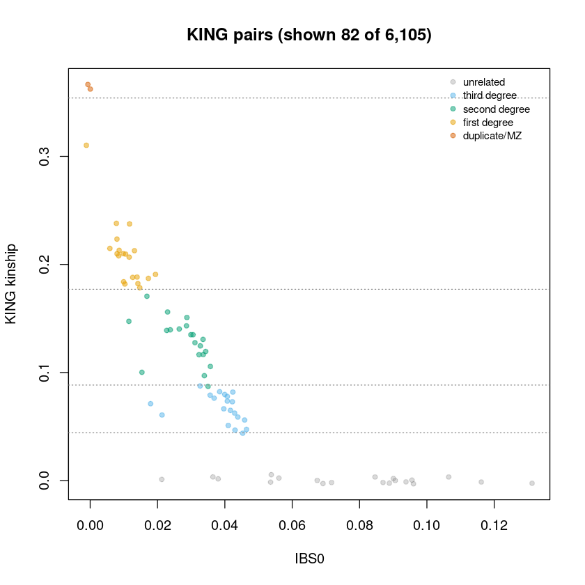

```
cat("Device dimensions:", dev.size("px"), "\n")

source(file.path(SCRIPTS, "plot_king_heatmap.R"))

plot_king_heatmap(
  king_file = "~/relatedness_animal/Reindeer_king.kin0"
)
```

```
Device dimensions: 480 480
```

```
Using FID as sample ID and IID as population ID
```

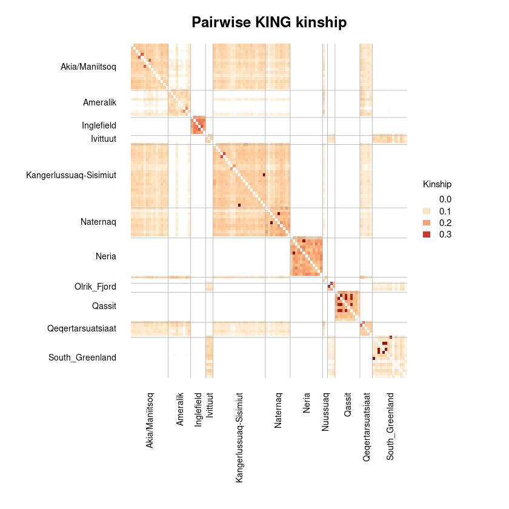

**Does the first graph look familiar?** Remember the presentation

**And how do you interprete the red values in the heatmap?**

## STEP 3 — Remove the related individuals

Considering we have related individuals in the dataset, we should remove them. The stardart is to remove 1st degree or closer

```
# run to start quiz
from jupyterquiz import display_quiz
display_quiz('https://raw.githubusercontent.com/popgenDK/courses/main/current_exercises/relatedness_diversity/quiz/king.json')
```

```
source ~/relatedness_animal/env.sh

# Extract pairs with kinship > 0.177 (1st degree or closer)
awk 'NR>1 && $8 > 0.177 {print $1"\n"$3}' Reindeer_king.kin0 \
  | sort -u > relatives_to_flag.txt

echo "Individuals to consider removing: $(wc -l < relatives_to_flag.txt)"
```

```
Individuals to consider removing: 63
```

Now we should see if removing the related individuals has an impact in our results:

```
source ~/relatedness_animal/env.sh

echo ---- Calculate the pca with all individuals -----
plink2 \
  --bfile Reindeer_pruned \
  --pca 10 \
  --out pca_Wrelated
echo
echo ---- Calculate the pca after removing related individuals----
plink2 \
  --bfile Reindeer_pruned \
  --king-cutoff-table Reindeer_king.kin0 0.177 \
  --pca 10 \
  --out pca_Nonrelated
```

```
---- Calculate the pca with all individuals -----
PLINK v2.00a6LM AVX2 Intel (6 Aug 2024)        www.cog-genomics.org/plink/2.0/
(C) 2005-2024 Shaun Purcell, Christopher Chang   GNU General Public License v3
Logging to pca_Wrelated.log.
Options in effect:
  --bfile Reindeer_pruned
  --out pca_Wrelated
  --pca 10

Start time: Wed Sep 16 20:03:14 2026
386830 MiB RAM detected, ~369098 available; reserving 193415 MiB for main
workspace.
Using up to 88 threads (change this with --threads).
111 samples (0 females, 0 males, 111 ambiguous; 111 founders) loaded from
Reindeer_pruned.fam.
4399 variants loaded from Reindeer_pruned.bim.
Note: No phenotype data present.
Calculating allele frequencies... 0%done.
Constructing GRM: 0%3%6%9%13%16%19%22%26%29%32%36%39%42%45%49%52%55%58%62%65%68%72%75%78%81%85%88%91%94%98%done.
Correcting for missingness... 0%33%66%done.
Extracting eigenvalues and eigenvectors... done.
--pca: Eigenvectors written to pca_Wrelated.eigenvec , and eigenvalues written
to pca_Wrelated.eigenval .
End time: Wed Sep 16 20:03:14 2026

---- Calculate the pca after removing related individuals----
PLINK v2.00a6LM AVX2 Intel (6 Aug 2024)        www.cog-genomics.org/plink/2.0/
(C) 2005-2024 Shaun Purcell, Christopher Chang   GNU General Public License v3
Logging to pca_Nonrelated.log.
Options in effect:
  --bfile Reindeer_pruned
  --king-cutoff-table Reindeer_king.kin0 0.177
  --out pca_Nonrelated
  --pca 10

Start time: Wed Sep 16 20:03:14 2026
386830 MiB RAM detected, ~369102 available; reserving 193415 MiB for main
workspace.
Using up to 88 threads (change this with --threads).
111 samples (0 females, 0 males, 111 ambiguous; 111 founders) loaded from
Reindeer_pruned.fam.
4399 variants loaded from Reindeer_pruned.bim.
Note: No phenotype data present.
Calculating allele frequencies... 0%done.
--king-cutoff-table: 136 constraints loaded.
--king-cutoff-table: Excluded sample IDs written to
pca_Nonrelated.king.cutoff.out.id , and 73 remaining sample IDs written to
pca_Nonrelated.king.cutoff.in.id .
Constructing GRM: 0%3%6%9%13%16%19%22%26%29%32%36%39%42%45%49%52%55%58%62%65%68%72%75%78%81%85%88%91%94%98%done.
Correcting for missingness... 0%34%68%done.
Extracting eigenvalues and eigenvectors... done.
--pca: Eigenvectors written to pca_Nonrelated.eigenvec , and eigenvalues
written to pca_Nonrelated.eigenval .
End time: Wed Sep 16 20:03:14 2026
```

```
options(
    repr.plot.width = 11,
    repr.plot.height = 8,
    repr.plot.res = 120
  )

source(file.path(SCRIPTS, "plot_pca_king.R"))

plot_pca_before_after(
    before_eigenvec = "~/relatedness_animal/pca_Wrelated.eigenvec",
    after_eigenvec  = "~/relatedness_animal/pca_Nonrelated.eigenvec",
    population_file = file.path(DATA, "population.tsv")
  )
```

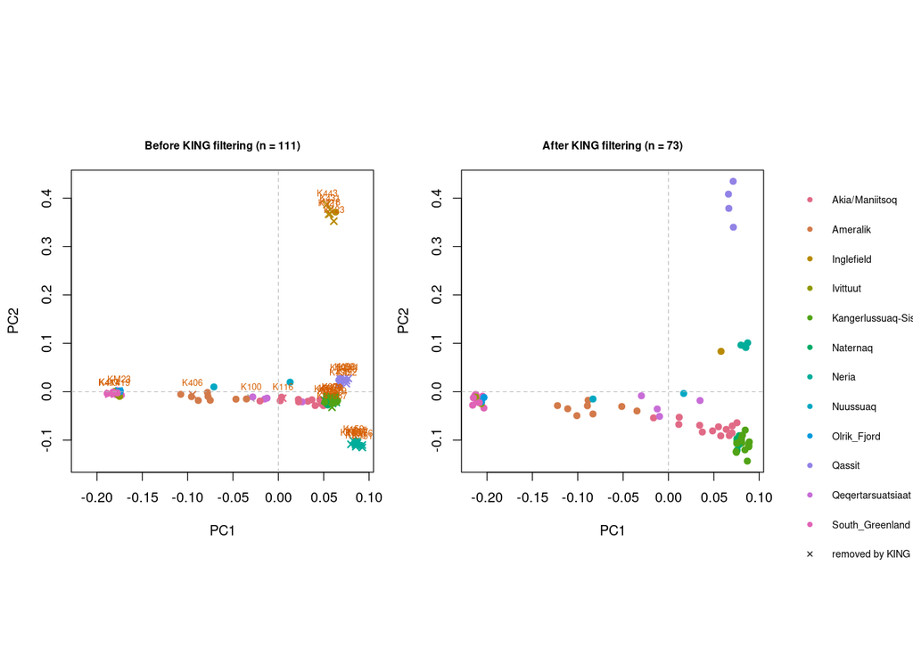

**Do you see any differences? Is it important to remove related individuals?**

**Important**: In a real analysis you would remove one individual from each related pair (keeping the one with more data/higher coverage) before running ADMIXTURE, PCA, or FST.

```
# run to start quiz
from jupyterquiz import display_quiz
display_quiz('https://raw.githubusercontent.com/popgenDK/courses/main/current_exercises/relatedness_diversity/quiz/relatedness_filtering.json')
```

# Reindeer admixture-aware relatedness with relateAdmix

`relateAdmix` estimates relatedness while conditioning on individual ancestry. It combines the LD-pruned PLINK dataset with ADMIXTURE's individual ancestry proportions (`.Q`) and ancestral-population allele frequencies (`.P`).

We reuse `Reindeer_pruned` from the PCAone/PLINK section. The `.Q` rows must match FAM sample order, and the `.P` rows must match BIM marker order.

```
source ~/relatedness_animal/env.sh

cd $WORK

# K=2 keeps this run short. A full analysis should compare K values and seeds.
# admixture writes its output into the current directory, which is $WORK.
admixture --cv=5 -s 2026 Reindeer_pruned.bed 2 | tee admixture.K2.log
echo
echo ----Check matching dimensions----
wc -l Reindeer_pruned.fam Reindeer_pruned.2.Q
wc -l Reindeer_pruned.bim Reindeer_pruned.2.P
```

```
****                   ADMIXTURE Version 1.3.0                  ****
****                    Copyright 2008-2015                     ****
****           David Alexander, Suyash Shringarpure,            ****
****                John  Novembre, Ken Lange                   ****
****                                                            ****
****                 Please cite our paper!                     ****
****   Information at www.genetics.ucla.edu/software/admixture  ****

Cross-validation will be performed.  Folds=5.
Random seed: 2026
Point estimation method: Block relaxation algorithm
Convergence acceleration algorithm: QuasiNewton, 3 secant conditions
Point estimation will terminate when objective function delta < 0.0001
Estimation of standard errors disabled; will compute point estimates only.
Size of G: 111x4399
Performing five EM steps to prime main algorithm
1 (EM) 	Elapsed: 0.016	Loglikelihood: -388628	(delta): 416090
2 (EM) 	Elapsed: 0.016	Loglikelihood: -377646	(delta): 10982.2
3 (EM) 	Elapsed: 0.016	Loglikelihood: -374549	(delta): 3096.77
4 (EM) 	Elapsed: 0.016	Loglikelihood: -372845	(delta): 1703.93
5 (EM) 	Elapsed: 0.016	Loglikelihood: -371810	(delta): 1035.08
Initial loglikelihood: -371810
Starting main algorithm
1 (QN/Block) 	Elapsed: 0.051	Loglikelihood: -350577	(delta): 21232.9
2 (QN/Block) 	Elapsed: 0.049	Loglikelihood: -346437	(delta): 4140.64
3 (QN/Block) 	Elapsed: 0.059	Loglikelihood: -344400	(delta): 2036.12
4 (QN/Block) 	Elapsed: 0.058	Loglikelihood: -342535	(delta): 1865.66
5 (QN/Block) 	Elapsed: 0.066	Loglikelihood: -342066	(delta): 468.333
6 (QN/Block) 	Elapsed: 0.062	Loglikelihood: -341964	(delta): 101.979
7 (QN/Block) 	Elapsed: 0.062	Loglikelihood: -341927	(delta): 37.1713
8 (QN/Block) 	Elapsed: 0.07	Loglikelihood: -341925	(delta): 2.15576
9 (QN/Block) 	Elapsed: 0.058	Loglikelihood: -341924	(delta): 1.23325
10 (QN/Block) 	Elapsed: 0.058	Loglikelihood: -341924	(delta): 0.0075326
11 (QN/Block) 	Elapsed: 0.062	Loglikelihood: -341924	(delta): 3.11469e-07
Summary:
Converged in 11 iterations (0.817 sec)
Loglikelihood: -341923.925347
Fst divergences between estimated populations:
	Pop0
Pop0
Pop1	0.262
CV error (K=2): 0.42263
Writing output files.

----Check matching dimensions----
 111 Reindeer_pruned.fam
 111 Reindeer_pruned.2.Q
 222 total
  4399 Reindeer_pruned.bim
  4399 Reindeer_pruned.2.P
  8798 total
```

```
source ~/relatedness_animal/env.sh

## If it takes too long, remove the hastag from this next command and run it.
#cp $DATA/Reindeer_pruned.2.* $WORK/.
```

### Plot the ADMIXTURE results

Each vertical bar represents one individual, and each colour represents the proportion assigned to one of the two inferred ancestry components. Individuals are grouped by population.

```
work_dir <- path.expand("~/relatedness_animal")

Q <- as.matrix(read.table(file.path(work_dir, "Reindeer_pruned.2.Q")))
fam <- read.table(file.path(work_dir, "Reindeer_pruned.fam"),
                  stringsAsFactors = FALSE)
stopifnot(nrow(Q) == nrow(fam))

population <- fam[, 2]
order_by_population <- order(population)
Q <- Q[order_by_population, , drop = FALSE]
population <- population[order_by_population]

ancestry_colours <- hcl.colors(ncol(Q), palette = "Dark 3")
population_runs <- rle(population)
group_ends <- cumsum(population_runs$lengths)
group_starts <- c(1, head(group_ends, -1) + 1)

options(repr.plot.width = 14, repr.plot.height = 6)
par(mar = c(9, 4, 3, 1))
bar_positions <- barplot(
  t(Q), col = ancestry_colours, border = NA, space = 0, axes = FALSE,
  ylab = "Ancestry proportion", main = "Reindeer ADMIXTURE results (K = 2)"
)
axis(2, las = 1)
group_centres <- vapply(seq_along(group_starts), function(i)
  mean(bar_positions[group_starts[i]:group_ends[i]]), numeric(1))
axis(1, at = group_centres, labels = population_runs$values,
     las = 2, tick = FALSE, cex.axis = 0.8)
if (length(group_ends) > 1)
  abline(v = bar_positions[group_ends[-length(group_ends)]] + 0.5,
         col = "white", lwd = 1)
legend("topright", legend = paste0("Ancestry ", seq_len(ncol(Q))),
       fill = ancestry_colours, border = NA, bty = "n")
```

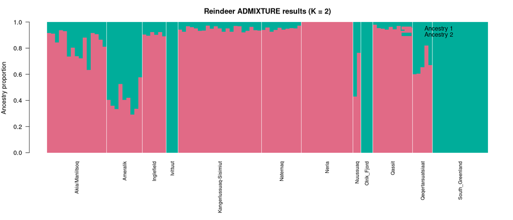

**Which are the major problems with the previous step, considering what you learned about admixture results validation yesterday?**

### Calculate relateAdmix

```
source ~/relatedness_animal/env.sh

cd $WORK

"$RELATEADMIX" -plink Reindeer_pruned \
  -fname Reindeer_pruned.2.P \
  -qname Reindeer_pruned.2.Q \
  -o Reindeer_relateAdmix_K2 -P 4

echo ----First relateAdmix output rows----
head Reindeer_relateAdmix_K2
```

```
/course/data/current_data/relatedness/relateAdmix -plink Reindeer_pruned -fname Reindeer_pruned.2.P -qname Reindeer_pruned.2.Q -o Reindeer_relateAdmix_K2 -P 4
	-> Will assume these are the plink files:
		bed: Reindeer_pruned.bed
		bim: Reindeer_pruned.bim
		fam: Reindeer_pruned.fam
	-> Plink file contains 4399 autosomale SNPs
	-> reading genotypes  - done
	-> sorting  - done
		->K=2	nSites=4399	nInd=111
opening : Reindeer_pruned.2.Q with x=111 y=2
opening : Reindeer_pruned.2.P with x=4399 y=2
running i1:107 i2:109
	[ALL done] cpu-time used =  4.49 sec
	[ALL done] walltime used =  1.00 sec
	[ALL done] results have been outputted to Reindeer_relateAdmix_K2
----First relateAdmix output rows----
ind1	ind2	k0	k1	k2	nIter
0	1	0.367850	0.539466	0.092684	38
0	2	0.965193	0.000000	0.034807	29
0	3	0.928763	0.000004	0.071233	32
0	4	0.998978	0.000499	0.000523	1
0	5	0.963548	0.000067	0.036385	32
0	6	0.932776	0.000059	0.067165	29
0	7	0.962125	0.000053	0.037822	26
0	8	0.909239	0.000080	0.090680	59
0	9	0.941005	0.000003	0.058991	38
```

**Do the `.Q` and FAM row counts match? Do the `.P` and BIM row counts match?** You should check the results for FAM and BIM that you measured before. Please run the command yourself - open a new promp and make sure you are using bash (to the right) and run the command that you used above to measure it in the FAM and BIM

### Comparing KING and relateAdmix relatedness estimates

KING estimates kinship directly from the genotype data, whereas relateAdmix accounts for each individual's estimated ancestry.

RelateAdmix reports the probabilities that a pair shares zero, one, or two alleles identical by descent (`k0`, `k1`, and `k2`). We convert these probabilities to a kinship coefficient:

[ \phi = \frac{k_1}{4} + \frac{k_2}{2} ]

The scatter plot compares this ancestry-adjusted estimate with the KING estimate. The dashed lines indicate the first-degree kinship threshold of 0.177.

Pairs in the upper-right quadrant are classified as first-degree relatives by both methods. Pairs to the right of the vertical line but below the horizontal line have high KING kinship but lower ancestry-adjusted relatedness.

```
##read and combine the results

work_dir <- path.expand("~/relatedness_animal")

# Read the PLINK sample information.
fam <- read.table(
  file.path(work_dir, "Reindeer_pruned.fam"),
  stringsAsFactors = FALSE
 )
colnames(fam)[1:2] <- c("FID", "IID")

# Read relateAdmix output.
relate <- read.table(
  file.path(work_dir, "Reindeer_relateAdmix_K2"),
  header = TRUE,
  stringsAsFactors = FALSE
  )

# relateAdmix uses zero-based row numbers from the FAM file.
relate$FID1 <- fam$FID[relate$ind1 + 1]
relate$IID1 <- fam$IID[relate$ind1 + 1]
relate$FID2 <- fam$FID[relate$ind2 + 1]
relate$IID2 <- fam$IID[relate$ind2 + 1]

# Convert IBD probabilities to a kinship coefficient.
relate$RELATE_KINSHIP <- relate$k1 / 4 + relate$k2 / 2

# Read the KING table.
king <- read.table(
  file.path(work_dir, "Reindeer_king.kin0"),
  header = TRUE,
  comment.char = "",
  check.names = FALSE,
  stringsAsFactors = FALSE
  )

# PLINK may place "#" before the first column name.
names(king) <- sub("^#", "", names(king))

# Create an order-independent identifier for each pair.
pair_key <- function(fid1, iid1, fid2, iid2) {
  sample1 <- paste(fid1, iid1, sep = ":")
  sample2 <- paste(fid2, iid2, sep = ":")

  ifelse(
    sample1 < sample2,
    paste(sample1, sample2, sep = " | "),
    paste(sample2, sample1, sep = " | ")
  )
}

relate$PAIR <- pair_key(
  relate$FID1, relate$IID1,
  relate$FID2, relate$IID2
)

king$PAIR <- pair_key(
  king$FID1, king$IID1,
  king$FID2, king$IID2
)

comparison <- merge(
  king[, c("PAIR", "KINSHIP")],
  relate[, c(
    "PAIR", "FID1", "IID1", "FID2", "IID2",
    "k0", "k1", "k2", "RELATE_KINSHIP"
  )],
  by = "PAIR"
)

cat("KING pairs:", nrow(king), "\n")
cat("relateAdmix pairs:", nrow(relate), "\n")
cat("Matched pairs:", nrow(comparison), "\n")
```

```
KING pairs: 6105
relateAdmix pairs: 6105
Matched pairs: 6105
```

**Question**

- This joins the KING and relateAdmix estimates for the same pairs. Why would the two disagree at all, given they use the same genotypes?

### KING versus relateAdmix

Each point represents a pair of individuals:

- Grey: below the threshold with both methods.
- Purple: above the threshold with both methods.
- Orange: above the threshold with KING only.
- Blue: above the threshold with relateAdmix only.

The diagonal line represents equal estimates from the two methods.

```
##main scatter plot

  kinship_cutoff <- 0.177

  comparison$classification <- with(
    comparison,
    ifelse(
      KINSHIP >= kinship_cutoff &
        RELATE_KINSHIP >= kinship_cutoff,
      "Both methods",
      ifelse(
        KINSHIP >= kinship_cutoff,
        "KING only",
        ifelse(
          RELATE_KINSHIP >= kinship_cutoff,
          "relateAdmix only",
          "Below threshold"
        )
      )
    )
  )

  point_colours <- c(
    "Below threshold" = adjustcolor("grey50", alpha.f = 0.35),
    "Both methods" = "#7B3294",
    "KING only" = "#E66101",
    "relateAdmix only" = "#0571B0"
  )

  options(repr.plot.width = 8, repr.plot.height = 7)

  plot(
    comparison$KINSHIP,
    comparison$RELATE_KINSHIP,
    pch = 16,
    cex = 0.8,
    col = point_colours[comparison$classification],
    xlab = "KING kinship coefficient",
    ylab = "relateAdmix kinship coefficient",
    main = "KING versus ancestry-adjusted relatedness"
  )

  # Equal estimates
  abline(a = 0, b = 1, col = "grey50", lty = 3)

  # First-degree threshold
  abline(
    v = kinship_cutoff,
    h = kinship_cutoff,
    col = "firebrick",
    lty = 2,
    lwd = 2
  )

  legend(
    "topleft",
    legend = names(point_colours),
    col = point_colours,
    pch = 16,
    bty = "n"
  )
```

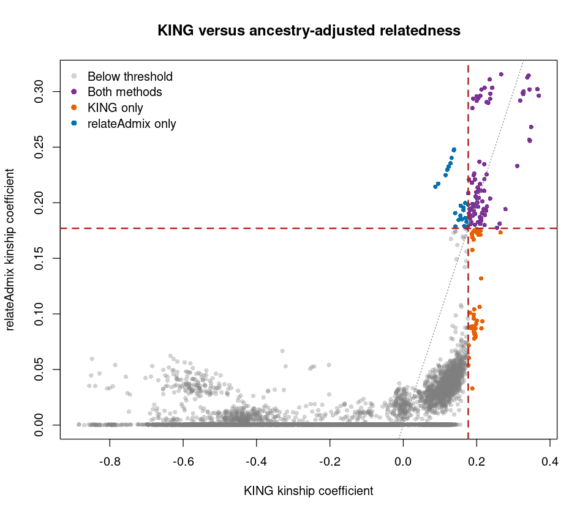

**Questions**

```
### Optional: inspect discordant pairs

  discordant_pairs <- subset(
    comparison,
    (KINSHIP >= kinship_cutoff) !=
      (RELATE_KINSHIP >= kinship_cutoff)
  )

  discordant_pairs <- discordant_pairs[
    order(
      abs(
        discordant_pairs$KINSHIP -
          discordant_pairs$RELATE_KINSHIP
      ),
      decreasing = TRUE
    ),
  ]

  discordant_pairs[, c(
    "FID1", "IID1", "FID2", "IID2",
    "KINSHIP", "RELATE_KINSHIP", "classification"
  )]
```

A data.frame: 71 × 7

|  | FID1 <chr> | IID1 <chr> | FID2 <chr> | IID2 <chr> | KINSHIP <dbl> | RELATE_KINSHIP <dbl> | classification <chr> |
| --- | --- | --- | --- | --- | --- | --- | --- |
| 105 | K100 | Qeqertarsuatsiaat | K528 | Nuussuaq | 0.1881850 | 0.03288800 | KING only |
| 5955 | K503 | Qassit | K508 | Qassit | 0.0876437 | 0.21439225 | relateAdmix only |
| 5247 | K475 | Naternaq | K479 | Naternaq | 0.2129870 | 0.08694550 | KING only |
| 2494 | K177 | Kangerlussuaq-Sisimiut | K475 | Naternaq | 0.1772020 | 0.05359525 | KING only |
| 5860 | K498 | Qassit | K508 | Qassit | 0.0949140 | 0.21716700 | relateAdmix only |
| 5203 | K474 | Naternaq | K475 | Naternaq | 0.2153880 | 0.09338600 | KING only |
| 2457 | K177 | Kangerlussuaq-Sisimiut | K371 | Kangerlussuaq-Sisimiut | 0.1789360 | 0.06042925 | KING only |
| 2502 | K177 | Kangerlussuaq-Sisimiut | K484 | Kangerlussuaq-Sisimiut | 0.1976270 | 0.07993975 | KING only |
| 5206 | K474 | Naternaq | K479 | Naternaq | 0.1958870 | 0.07896950 | KING only |
| 5245 | K475 | Naternaq | K477 | Naternaq | 0.1933560 | 0.07780525 | KING only |
| 5287 | K477 | Naternaq | K479 | Naternaq | 0.1960570 | 0.08235150 | KING only |
| 2501 | K177 | Kangerlussuaq-Sisimiut | K483 | Kangerlussuaq-Sisimiut | 0.1935210 | 0.08201500 | KING only |
| 5791 | K492 | Qassit | K508 | Qassit | 0.1380920 | 0.24798150 | relateAdmix only |
| 5881 | K499 | Qassit | K508 | Qassit | 0.1197840 | 0.22966225 | relateAdmix only |
| 5074 | K471 | Naternaq | K475 | Naternaq | 0.1965560 | 0.08692800 | KING only |
| 5920 | K501 | Qassit | K508 | Qassit | 0.1153300 | 0.22489300 | relateAdmix only |
| 5938 | K502 | Qassit | K508 | Qassit | 0.1377700 | 0.24719000 | relateAdmix only |
| 5901 | K500 | Qassit | K508 | Qassit | 0.1314660 | 0.24036475 | relateAdmix only |
| 5164 | K473 | Naternaq | K479 | Naternaq | 0.1923740 | 0.08368075 | KING only |
| 5815 | K493 | Qassit | K508 | Qassit | 0.1239220 | 0.23252100 | relateAdmix only |
| 5204 | K474 | Naternaq | K477 | Naternaq | 0.1982980 | 0.09090875 | KING only |
| 5838 | K496 | Qassit | K508 | Qassit | 0.1286020 | 0.23554075 | relateAdmix only |
| 5160 | K473 | Naternaq | K474 | Naternaq | 0.1781170 | 0.07153125 | KING only |
| 4983 | K468 | Naternaq | K475 | Naternaq | 0.2004820 | 0.09395150 | KING only |
| 5077 | K471 | Naternaq | K479 | Naternaq | 0.1922040 | 0.08753025 | KING only |
| 5162 | K473 | Naternaq | K477 | Naternaq | 0.1888840 | 0.08696475 | KING only |
| 4215 | K41660 | Kangerlussuaq-Sisimiut | K41667 | Kangerlussuaq-Sisimiut | 0.2080480 | 0.10622000 | KING only |
| 5246 | K475 | Naternaq | K478 | Naternaq | 0.1886280 | 0.08888925 | KING only |
| 4986 | K468 | Naternaq | K479 | Naternaq | 0.1837270 | 0.08731900 | KING only |
| 5075 | K471 | Naternaq | K477 | Naternaq | 0.1916890 | 0.09606850 | KING only |
| ⋮ | ⋮ | ⋮ | ⋮ | ⋮ | ⋮ | ⋮ | ⋮ |
| 5935 | K502 | Qassit | K503 | Qassit | 0.150908 | 0.1846090 | relateAdmix only |
| 5974 | K505 | Neria | K512 | Neria | 0.204985 | 0.1713143 | KING only |
| 5916 | K501 | Qassit | K502 | Qassit | 0.155882 | 0.1884838 | relateAdmix only |
| 5877 | K499 | Qassit | K502 | Qassit | 0.163987 | 0.1956835 | relateAdmix only |
| 5834 | K496 | Qassit | K502 | Qassit | 0.176849 | 0.2085410 | relateAdmix only |
| 5856 | K498 | Qassit | K502 | Qassit | 0.168810 | 0.1997970 | relateAdmix only |
| 5970 | K505 | Neria | K507 | Neria | 0.188119 | 0.1575187 | KING only |
| 2084 | K151 | Neria | K505 | Neria | 0.201857 | 0.1724347 | KING only |
| 5811 | K493 | Qassit | K502 | Qassit | 0.164263 | 0.1935183 | relateAdmix only |
| 5787 | K492 | Qassit | K502 | Qassit | 0.156350 | 0.1854175 | relateAdmix only |
| 2439 | K156 | Neria | K512 | Neria | 0.202117 | 0.1736758 | KING only |
| 1921 | K148 | Neria | K152 | Neria | 0.159977 | 0.1852310 | relateAdmix only |
| 5989 | K507 | Neria | K512 | Neria | 0.200791 | 0.1757952 | KING only |
| 2179 | K152 | Neria | K513 | Neria | 0.191633 | 0.1669303 | KING only |
| 2434 | K156 | Neria | K505 | Neria | 0.198180 | 0.1744388 | KING only |
| 5990 | K507 | Neria | K513 | Neria | 0.199900 | 0.1763258 | KING only |
| 6051 | K513 | Neria | K515 | Neria | 0.196553 | 0.1743310 | KING only |
| 2000 | K148 | Neria | K513 | Neria | 0.176759 | 0.1983065 | relateAdmix only |
| 5975 | K505 | Neria | K513 | Neria | 0.194444 | 0.1751585 | KING only |
| 2103 | K152 | Neria | K156 | Neria | 0.188064 | 0.1690922 | KING only |
| 6016 | K510 | Neria | K512 | Neria | 0.190783 | 0.1738300 | KING only |
| 2001 | K148 | Neria | K515 | Neria | 0.169540 | 0.1863877 | relateAdmix only |
| 5972 | K505 | Neria | K510 | Neria | 0.187129 | 0.1716352 | KING only |
| 2437 | K156 | Neria | K510 | Neria | 0.187563 | 0.1724622 | KING only |
| 5812 | K493 | Qassit | K503 | Qassit | 0.166234 | 0.1790503 | relateAdmix only |
| 2348 | K154 | Neria | K505 | Neria | 0.172703 | 0.1829387 | relateAdmix only |
| 2355 | K154 | Neria | K515 | Neria | 0.173596 | 0.1782340 | relateAdmix only |
| 2349 | K154 | Neria | K507 | Neria | 0.173139 | 0.1774777 | relateAdmix only |
| 2353 | K154 | Neria | K512 | Neria | 0.174406 | 0.1784447 | relateAdmix only |
| 5988 | K507 | Neria | K511 | Neria | 0.175239 | 0.1787373 | relateAdmix only |

**Question**

- Look at the discordant pairs. Do they involve individuals from the same population or different ones, and does that fit the explanation that KING is confounded by structure?

### Heatmap of ancestry-adjusted relatedness

The heatmap summarizes relateAdmix kinship estimates for every pair of individuals. Samples are ordered by population so that within-population and between-population patterns are easier to recognize.

The diagonal is left blank because it represents self-comparisons rather than pairwise relatedness estimates.

```
###supporting heatmap

  sample_labels <- paste(fam$FID, fam$IID, sep = ":")
  number_of_samples <- nrow(fam)

  relate_matrix <- matrix(
    0,
    nrow = number_of_samples,
    ncol = number_of_samples,
    dimnames = list(sample_labels, sample_labels)
  )

  row_index <- relate$ind1 + 1
  column_index <- relate$ind2 + 1

  relate_matrix[
    cbind(row_index, column_index)
  ] <- relate$RELATE_KINSHIP

  relate_matrix[
    cbind(column_index, row_index)
  ] <- relate$RELATE_KINSHIP

  diag(relate_matrix) <- NA

  # The second FAM column contains the population labels in this dataset.
  population <- fam$IID
  sample_order <- order(population)

  relate_matrix <- relate_matrix[
    sample_order,
    sample_order
  ]

  ordered_population <- population[sample_order]
  population_runs <- rle(ordered_population)
  group_ends <- cumsum(population_runs$lengths)
  group_starts <- c(1, head(group_ends, -1) + 1)
  group_centres <- (group_starts + group_ends) / 2

  heat_colours <- colorRampPalette(
    c("white", "#FEE8C8", "#FDBB84", "#E34A33", "#7F0000")
  )(100)

  options(repr.plot.width = 10, repr.plot.height = 9)
  par(mar = c(9, 9, 3, 7))

  kinship_range <- range(relate_matrix, na.rm = TRUE)

  image(
    x = seq_len(number_of_samples),
    y = seq_len(number_of_samples),
    z = t(relate_matrix[number_of_samples:1, ]),
    col = heat_colours,
    zlim = kinship_range,
    axes = FALSE,
    xlab = "",
    ylab = "",
    main = "relateAdmix ancestry-adjusted kinship"
  )

  axis(
    1,
    at = group_centres,
    labels = population_runs$values,
    las = 2,
    tick = FALSE,
    cex.axis = 0.7
  )

  axis(
    2,
    at = number_of_samples + 1 - rev(group_centres),
    labels = rev(population_runs$values),
    las = 2,
    tick = FALSE,
    cex.axis = 0.7
  )

  if (length(group_ends) > 1) {
    boundaries <- group_ends[-length(group_ends)] + 0.5

    abline(v = boundaries, col = "grey70", lwd = 0.7)
    abline(
      h = number_of_samples + 0.5 - boundaries,
      col = "grey70",
      lwd = 0.7
    )
  }

  # Add the colour legend after drawing the heatmap.
  legend_values <- pretty(kinship_range, n = 5)
  legend_values <- legend_values[
    legend_values >= kinship_range[1] &
      legend_values <= kinship_range[2]
  ]

  if (diff(kinship_range) == 0) {
    legend_colours <- heat_colours[50]
  } else {
    legend_colours <- heat_colours[
      round(
        1 + 99 *
          (legend_values - kinship_range[1]) /
          diff(kinship_range)
      )
    ]
  }

  legend(
    "right",
    inset = c(-0.19, 0),
    legend = format(legend_values, digits = 3, trim = TRUE),
    fill = legend_colours,
    border = NA,
    title = "Kinship",
    bty = "n",
    xpd = NA,
    cex = 0.75
  )
```

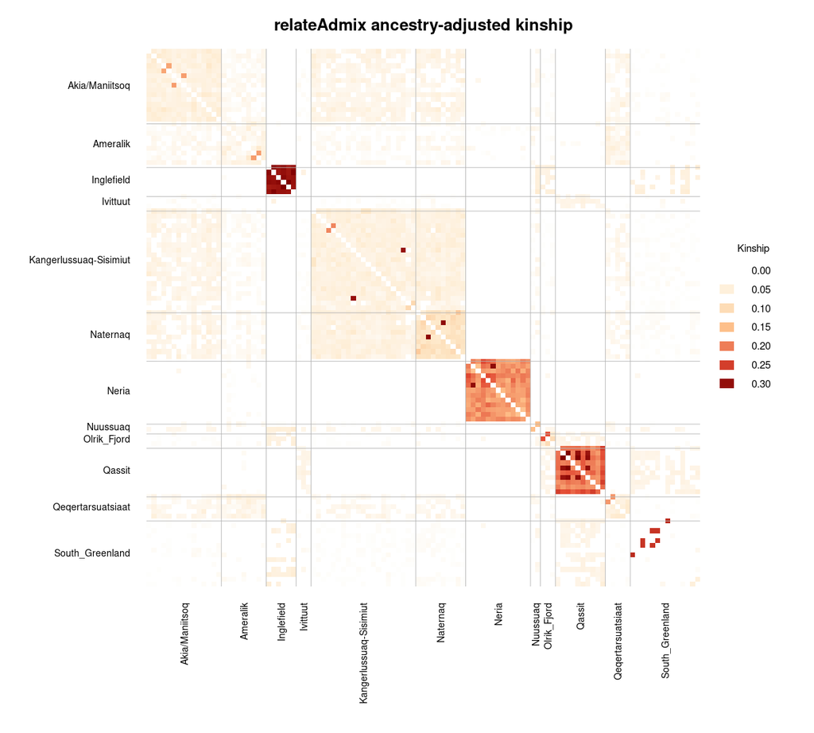

**Compare close pairs from KING and relateAdmix. Could population structure explain any disagreement?**

```
# run to start quiz
from jupyterquiz import display_quiz
display_quiz('https://raw.githubusercontent.com/popgenDK/courses/main/current_exercises/relatedness_diversity/quiz/relateadmix.json')
```